# Vessel Activity-Global Fishing Watch

Narjes Mathlouthi

2022-04-10

## Overview

This dataset contains the [Global Fishing Watch](https://globalfishingwatch.org/datasets-and-code/) AIS-based fishing effort and vessel presence datasets .Data is based on fishing detections of >114,000 unique AIS devices on fishing vessels, of which ~70,000 are active each year. Fishing vessels are identified via a neural network classifier, vessel registry databases, and manual review by GFW and regional experts. Data are binned into grid cells 0.01 (or 0.1) degrees on a side and measured in units of hours. The time is calculated by assigning an amount of time to each AIS detection (which is the time to the previous position), and then summing all positions in each grid cell.

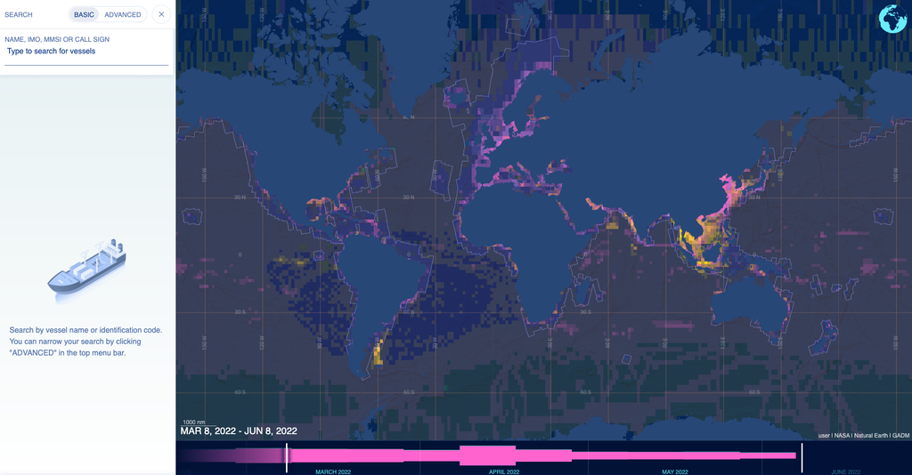

Fig 1.Map of Apparent Fishing Effort.

*Data are available in two formats:*

1. Fishing effort by flag state and gear type at 100th degree resolution
2. Fishing effort by MMSI at 10th degree resolution

Each version of the fishing effort dataset is accompanied by a table of vessel information (e.g. gear type, flag state, dimensions, etc.).

Note: When attempting to download multiple files, you will receive an email containing download links after the data has been packaged. For large requests, it may take up to 24 hours to receive this email.

*Versions*

The fishing effort data is updated periodically to include more recent data and as improvements are made to our models and input data. Data from different major/minor versions should not be combined, as each version uses a different set of inputs.

*Current version*

2.0: Fishing effort data for 2012-2020 using our latest AIS algorithms, neural network models, and vessel registry database.

## AIS Data

This MMSI number is usually unique to a single vessel and typically doesn’t change unless the vessel is reflagged. Most of the naval vessels we investigated did appear to use a particular MMSI number consistently even if the vessel only broadcast AIS occasionally. The MMSI numbers used by different naval vessels are listed on sites like MarineTraffic or even Wikipedia. But how can we really be sure that an MMSI number corresponds to a particular naval vessel? Naval vessels are frequently photographed, and it’s possible to get a sequence of port visits based on photos uploaded to sites like warshipcam.com. This documented series o f port visits can then be compared to the AIS track to confirm that an MMSI corresponds to a particular vessel.

## Data Wrangling & Exploration

In a snapshot, some of the steps for data exploration in this analysis include :

- Import data
- Clean data
- Format data properly
- Create new variables
- Get an overview about the complete data
- Split data into training and test set using stratified sampling
- Discover and visualize the data to gain insights

```r
knitr::opts_chunk$set(echo = TRUE, message = FALSE, warning = FALSE)
```

#### Load Packages

We will use several R packages to work with the data. The tidyverse package contains several helpful packages for data manipulation (dplyr, tidyr, readr) and plotting (ggplot2), `lubridate()` is great for working with dates. The `tidymodels()` package is key to this analysis for setting up all the models for machine learning.

```r
knitr::opts_chunk$set(echo = TRUE, message = FALSE, warning = FALSE)


# ### Geo Packages library(raster) # for working with rasters needs to run
# before tidyverse or select() wont work library(maps) # additional helpful
# mapping packages library(maptools) library(tmap) library(rgeos)
# library(gstat) library(sf) # for vector data
# #install.packages('rnaturalearth') library(rnaturalearth) library(sp)

### Data Cleaning & wrangling
library(tidyverse)  # for general data wrangling and plotting
library(purrr)
library(lubridate)  # for working with dates
library(here)  # for paths
library(janitor)  # for cleaning var names
library(formatR)  #used for chunk tidy code formatting
library(knitr)

### ML packages
library(tidymodels)
library(glmnet)  # Lasso and Elastic-Net Regularized Generalized Linear Models
library(vip)
library(randomForest)
library(ranger)  #for random forest
library(xgboost)
library(kableExtra)
library(readr)
library(corrr)
library(corrplot)
library(klaR)
library(tune)

### Visualization
library(corrplot)  # to create a correlation matrix
library(rpart.plot)  # for trees to plot an rpart model
# library(fishualize) # library(fishmethods)
library(GGally)
library(visdat)
library(skimr)
library(kableExtra)

### Query library(bigrquery) #Interface to Google's 'BigQuery' 'API'
```

## Import Data

Daily fishing effort data are available for download in the following two formats:

- Daily Fishing Effort and Vessel Presence at **100th** Degree Resolution by Flag State and GearType, 2012-2020
- Daily Fishing Effort and at **10th** Degree Resolution by MMSI, 2012-2020

Upon downloading each dataset, users will receive a `.zip` file containing a folder named fishing_effort (or fishing_effort_byvessel) that itself contains the data readme.txt file and the daily_csvs folder. The daily csvs are named according to the *YYYY-MM-DD.csv* format. The files generally increase in size over time due to the higher number of satellites receiving AIS data. Since we will be using both datasets, let’s rename the fishing_effort folder to fishing_effort_byflag and then store both the fishing_effort_byflag and fishing_effort_byvessel folders within a directory called fishing_effort.

Data containing details on the fishing vessels included in the fishing effort datasets are also available. These data can be used in conjunction with the “Daily Fishing Effort and at 10th Degree Resolution by MMSI” data to explore vessel and fleet characteristics and provide details (gear type, flag state, etc.) for the MMSI being analyzed.

#### Shapefiles

Shapefiles of land and Exclusive Economic Zone (EEZ) boundaries are useful for providing context to maps of fishing effort. For this analysis, we’ll use a land shapefile from the maps R package and an **EEZ shapefile** from **MarineRegions.org**. We’ll also load/convert both of these **shapefiles** to sf objects. The `sf` R package is a great package for working with vector data stored in dataframes, providing numerous functions for performing spatial operations.

#### World polygons from the maps package

```r
# load("world.Rda")
```

#### Load EEZ polygons

```r
# load("eezs.Rda")
```

## Loading the data

```r
# load vessels yearly data
load("vessels.Rda")
# head(vessels)
```

## Geartypes:

The current version of the GFW vessel classification neural net classifies fishing vessels into sixteen categories.

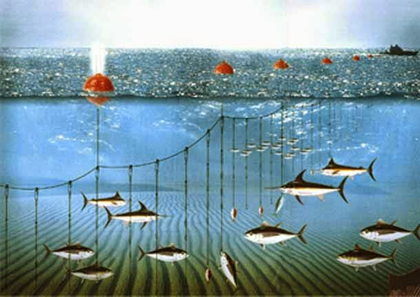

Longline fishermen use lines that can extend for up to 50 miles, with thousands of baited hooks branching off from the main line. Unfortunately, the baited hooks attract a vast array of species that are not intentionally targeted, including diving birds, turtles, etc. If an animal becomes hooked, it is often seriously injured or dead by the time the gear is retrieved. Using more selective gear instead of longlines is proven to reduce bycatch and improve fishing efficiency.(oceana.org)

Some classes of the outcome variable chosen for this analysis are described below :

- `fishing`: a combination of vessels of unknown fishing gear
- `drifting_longlines`: drifting longlines
- `seiners`: vessels using seine nets, including potential purse seine vessels targeting tuna and other species, as well as danish and other seines
- `purse_seines`: purse seines, both pelagic and demersal
- `tuna_purse_seines`: large purse seines primarily fishing for tuna.
- `other_purse_seines`: purse seiners fishing for mackerel, anchovies, etc, often smaller and operating nearer the coast than tuna purse seines.
- `other_seines`: danish seines and other seiners not using purse seines.
- `trawlers`: trawlers, all types
- `pole_and_line`: vessel from which people fish with pole and line.
- `trollers`: vessel that tows multiple fishing lines.
- `fixed_gear`: a category that includes potential set longlines, set gillnets, and pots and traps

## Exploratory Data Analysis

```r
# To get a first impression of the data we take a look at the top 4 rows:
# install.packages('gt')
library(gt)

# vessels data quick exploration
vessels %>%
    slice_head(n = 4) %>%
    gt()  # print output using gt
```

| mmsi | flag_ais | flag_registry | flag_gfw | vessel_class_inferred | vessel_class_inferred_score | vessel_class_registry | vessel_class_gfw | self_reported_fishing_vessel | length_m_inferred | length_m_registry | length_m_gfw | engine_power_kw_inferred | engine_power_kw_registry | engine_power_kw_gfw | tonnage_gt_inferred | tonnage_gt_registry | tonnage_gt_gfw | registries_listed | fishing_hours_2012 | fishing_hours_2013 | fishing_hours_2014 | fishing_hours_2015 | fishing_hours_2016 | fishing_hours_2017 | fishing_hours_2018 | fishing_hours_2019 | fishing_hours_2020 |
| --- | --- | --- | --- | --- | --- | --- | --- | --- | --- | --- | --- | --- | --- | --- | --- | --- | --- | --- | --- | --- | --- | --- | --- | --- | --- | --- | --- |
| 40120000 | NA | GRC | GRC | NA | NA | trawlers | trawlers | TRUE | NA | 26.30 | 26.30 | NA | 176.40 | 176.40 | NA | 133.00 | 133.00 | EU\|GFCM\|IMO | NA | NA | NA | NA | NA | NA | NA | NA | 674.10 |
| 444002410 | NA | KOR | KOR | NA | NA | tuna_purse_seines | tuna_purse_seines | FALSE | NA | 79.60 | 79.60 | NA | 3256.29 | 3256.29 | NA | 2132.33 | 2132.33 | FFA\|IMO\|ISSF\|KOR\|WCPFC\|WCPFC2 | NA | NA | NA | NA | NA | NA | NA | NA | 144.43 |
| 987654320 | NA | PHL | PHL | NA | NA | tuna_purse_seines | tuna_purse_seines | FALSE | NA | 66.40 | 66.40 | NA | 2219.27 | 2219.27 | NA | 1081.00 | 1081.00 | FFA\|ISSF\|WCPFC\|WCPFC2 | NA | NA | NA | NA | NA | NA | NA | NA | 545.33 |
| 554128120 | NA | NRU | NRU | NA | NA | tuna_purse_seines | tuna_purse_seines | FALSE | NA | 71.79 | 71.79 | NA | 2647.00 | 2647.00 | NA | 1350.00 | 1350.00 | FFA\|IMO\|ISSF\|TWN4\|WCPFC | NA | NA | NA | NA | NA | NA | NA | NA | 587.01 |

```r
# Creating and storing a table of yearly vessels geartype
vessels_gear <- vessels %>%
    group_by(vessel_class_gfw) %>%
    summarize(sum_class = n()) %>%
    arrange(desc(sum_class))

# Proportion of each vessel's geartype
vessels %>%
    count(vessel_class_gfw) %>%
    mutate(prop = n/sum(n)) %>%
    arrange(-(round(prop, 2))) %>%
    kable(caption = "Fishing Gear Class") %>%
    column_spec(1:3, width = "10em") %>%
    kable_styling(bootstrap_options = "striped")
```

Fishing Gear Class

| vessel_class_gfw | n | prop |
| --- | --- | --- |
| trawlers | 48494 | 0.4246744 |
| fishing | 19542 | 0.1711343 |
| set_longlines | 12313 | 0.1078281 |
| set_gillnets | 11487 | 0.1005946 |
| drifting_longlines | 4356 | 0.0381466 |
| fixed_gear | 4856 | 0.0425252 |
| other_purse_seines | 4369 | 0.0382605 |
| dredge_fishing | 1931 | 0.0169103 |
| pole_and_line | 2063 | 0.0180662 |
| pots_and_traps | 1364 | 0.0119449 |
| squid_jigger | 1276 | 0.0111743 |
| tuna_purse_seines | 1219 | 0.0106751 |
| other_seines | 106 | 0.0009283 |
| purse_seines | 376 | 0.0032927 |
| seiners | 100 | 0.0008757 |
| trollers | 339 | 0.0029687 |

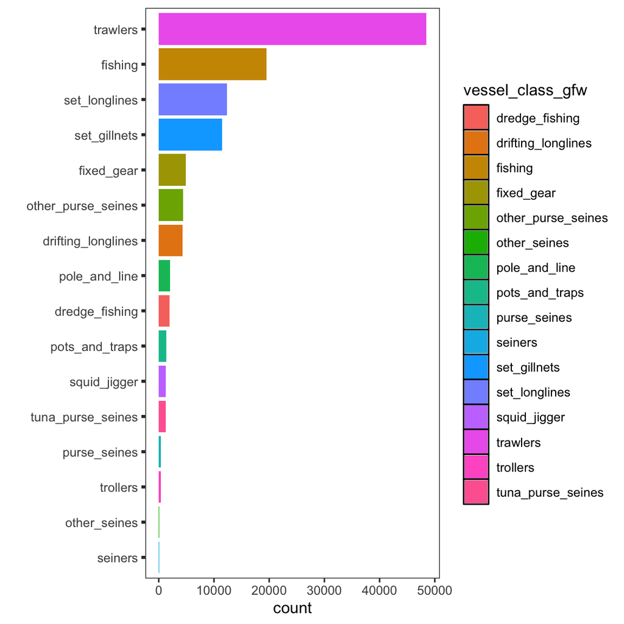

```r
# howw many geartypes in the dataset
vessels %>%
    ggplot(aes(x = reorder(vessel_class_gfw, vessel_class_gfw, function(x) length(x)))) +
    geom_bar(aes(fill = vessel_class_gfw, stat = "identity")) + theme_bw() + labs(x = "") +
    theme(axis.ticks.y = element_line(size = 1), panel.grid = element_blank(), legend.key = NULL) +
    coord_flip()
```